# Assignment2

Heeral s4653155

2022-03-22

## *Heeral* **s4653155**

# Assignment 2

### Loading the packages and dataset

```r
#install.package("tidyverse")
library(tidyverse)
thanksgiving <- read.csv("https://raw.githubusercontent.com/rfordatascience/tidytuesday/master/data/2018/2018-11-20/thanksgiving_meals.csv")
```

### 1. Display the first 10 rows of the dataset using ‘kable()’ function.

```r
#install.package("knitr")
library(knitr)

kable(thanksgiving[1:10,])
```

| id | celebrate | main_dish | main_dish_other | main_prep | main_prep_other | stuffing | stuffing_other | cranberry | cranberry_other | gravy | side1 | side2 | side3 | side4 | side5 | side6 | side7 | side8 | side9 | side10 | side11 | side12 | side13 | side14 | side15 | pie1 | pie2 | pie3 | pie4 | … |
| --- | --- | --- | --- | --- | --- | --- | --- | --- | --- | --- | --- | --- | --- | --- | --- | --- | --- | --- | --- | --- | --- | --- | --- | --- | --- | --- | --- | --- | --- | --- |
| 4337954960 | Yes | Turkey | NA | Baked | NA | Bread-based | NA | None | NA | Yes | NA | Carrots | NA | NA | NA | NA | Green beans/green bean casserole | Macaroni and cheese | Mashed potatoes | NA | NA | NA | Yams/sweet potato casserole | NA | NA | Apple | NA | NA | NA | … |
| 4337951949 | Yes | Turkey | NA | Baked | NA | Bread-based | NA | Other (please specify) | Homemade cranberry gelatin ring | Yes | NA | NA | NA | Corn | NA | NA | Green beans/green bean casserole | Macaroni and cheese | Mashed potatoes | Rolls/biscuits | NA | Vegetable salad | Yams/sweet potato casserole | Other (please specify) | Asian vinagrette salad | Apple | NA | NA | Chocolate | … |
| 4337935621 | Yes | Turkey | NA | Roasted | NA | Rice-based | NA | Homemade | NA | Yes | Brussel sprouts | Carrots | Cauliflower | Corn | Cornbread | NA | NA | NA | Mashed potatoes | Rolls/biscuits | NA | Vegetable salad | NA | NA | NA | Apple | NA | Cherry | NA | … |
| 4337933040 | Yes | Turkey | NA | Baked | NA | Bread-based | NA | Homemade | NA | Yes | Brussel sprouts | NA | NA | NA | Cornbread | NA | NA | NA | Mashed potatoes | Rolls/biscuits | NA | Vegetable salad | Yams/sweet potato casserole | NA | NA | NA | NA | NA | NA | … |
| 4337931983 | Yes | Tofurkey | NA | Baked | NA | Bread-based | NA | Canned | NA | Yes | Brussel sprouts | NA | NA | NA | Cornbread | NA | NA | NA | Mashed potatoes | Rolls/biscuits | Squash | Vegetable salad | Yams/sweet potato casserole | NA | NA | Apple | NA | NA | NA | … |
| 4337929779 | Yes | Turkey | NA | Roasted | NA | Rice-based | NA | Homemade | NA | Yes | Brussel sprouts | Carrots | Cauliflower | Corn | Cornbread | Fruit salad | Green beans/green bean casserole | Macaroni and cheese | Mashed potatoes | Rolls/biscuits | Squash | Vegetable salad | Yams/sweet potato casserole | NA | NA | NA | NA | NA | NA | … |
| 4337924420 | Yes | Turkey | NA | Baked | NA | Bread-based | NA | Canned | NA | Yes | NA | NA | NA | NA | NA | Fruit salad | Green beans/green bean casserole | NA | Mashed potatoes | Rolls/biscuits | NA | NA | Yams/sweet potato casserole | NA | NA | Apple | NA | NA | NA | … |
| 4337916002 | Yes | Turkey | NA | Baked | NA | Rice-based | NA | Homemade | NA | Yes | NA | Carrots | NA | NA | NA | NA | NA | NA | NA | NA | NA | NA | NA | NA | NA | NA | NA | NA | Chocolate | … |
| 4337914977 | Yes | Turkey | NA | Roasted | NA | Bread-based | NA | Canned | NA | Yes | Brussel sprouts | NA | NA | Corn | Cornbread | NA | Green beans/green bean casserole | NA | Mashed potatoes | Rolls/biscuits | Squash | NA | NA | NA | NA | Apple | Buttermilk | NA | NA | … |
| 4337899817 | Yes | Other (please specify) | Turkey and Ham | Baked | NA | Bread-based | NA | Other (please specify) | Both Canned and Homemade | Yes | Brussel sprouts | Carrots | NA | NA | NA | NA | Green beans/green bean casserole | NA | Mashed potatoes | Rolls/biscuits | NA | NA | Yams/sweet potato casserole | NA | NA | NA | Buttermilk | NA | NA | … |

### 2. Using ‘skim()’ display the summary of variables.

```r
#install.package("skimr")
library(skimr)

thanksgiving %>% skim()
```

Data summary

| Name | Piped data |
| --- | --- |
| Number of rows | 1058 |
| Number of columns | 65 |
| _______________________ |  |
| Column type frequency: |  |
| character | 64 |
| numeric | 1 |
| ________________________ |  |
| Group variables | None |

**Variable type: character**

| skim_variable | n_missing | complete_rate | min | max | empty | n_unique | whitespace |
| --- | --- | --- | --- | --- | --- | --- | --- |
| celebrate | 0 | 1.00 | 2 | 3 | 0 | 2 | 0 |
| main_dish | 84 | 0.92 | 6 | 22 | 0 | 8 | 0 |
| main_dish_other | 1023 | 0.03 | 4 | 85 | 0 | 32 | 0 |
| main_prep | 84 | 0.92 | 5 | 22 | 0 | 5 | 0 |
| main_prep_other | 1007 | 0.05 | 1 | 33 | 0 | 32 | 0 |
| stuffing | 84 | 0.92 | 4 | 22 | 0 | 4 | 0 |
| stuffing_other | 1022 | 0.03 | 4 | 46 | 0 | 29 | 0 |
| cranberry | 84 | 0.92 | 4 | 22 | 0 | 4 | 0 |
| cranberry_other | 1033 | 0.02 | 3 | 61 | 0 | 24 | 0 |
| gravy | 84 | 0.92 | 2 | 3 | 0 | 2 | 0 |
| side1 | 903 | 0.15 | 15 | 15 | 0 | 1 | 0 |
| side2 | 816 | 0.23 | 7 | 7 | 0 | 1 | 0 |
| side3 | 970 | 0.08 | 11 | 11 | 0 | 1 | 0 |
| side4 | 594 | 0.44 | 4 | 4 | 0 | 1 | 0 |
| side5 | 823 | 0.22 | 9 | 9 | 0 | 1 | 0 |
| side6 | 843 | 0.20 | 11 | 11 | 0 | 1 | 0 |
| side7 | 372 | 0.65 | 32 | 32 | 0 | 1 | 0 |
| side8 | 852 | 0.19 | 19 | 19 | 0 | 1 | 0 |
| side9 | 241 | 0.77 | 15 | 15 | 0 | 1 | 0 |
| side10 | 292 | 0.72 | 14 | 14 | 0 | 1 | 0 |
| side11 | 887 | 0.16 | 6 | 6 | 0 | 1 | 0 |
| side12 | 849 | 0.20 | 15 | 15 | 0 | 1 | 0 |
| side13 | 427 | 0.60 | 27 | 27 | 0 | 1 | 0 |
| side14 | 947 | 0.10 | 22 | 22 | 0 | 1 | 0 |
| side15 | 947 | 0.10 | 4 | 78 | 0 | 89 | 0 |
| pie1 | 544 | 0.49 | 5 | 5 | 0 | 1 | 0 |
| pie2 | 1023 | 0.03 | 10 | 10 | 0 | 1 | 0 |
| pie3 | 945 | 0.11 | 6 | 6 | 0 | 1 | 0 |
| pie4 | 925 | 0.13 | 9 | 9 | 0 | 1 | 0 |
| pie5 | 1022 | 0.03 | 13 | 13 | 0 | 1 | 0 |
| pie6 | 1019 | 0.04 | 8 | 8 | 0 | 1 | 0 |
| pie7 | 1024 | 0.03 | 5 | 5 | 0 | 1 | 0 |
| pie8 | 716 | 0.32 | 5 | 5 | 0 | 1 | 0 |
| pie9 | 329 | 0.69 | 7 | 7 | 0 | 1 | 0 |
| pie10 | 906 | 0.14 | 12 | 12 | 0 | 1 | 0 |
| pie11 | 1018 | 0.04 | 4 | 4 | 0 | 1 | 0 |
| pie12 | 987 | 0.07 | 22 | 22 | 0 | 1 | 0 |
| pie13 | 987 | 0.07 | 5 | 46 | 0 | 61 | 0 |
| dessert1 | 948 | 0.10 | 13 | 13 | 0 | 1 | 0 |
| dessert2 | 1042 | 0.02 | 8 | 8 | 0 | 1 | 0 |
| dessert3 | 930 | 0.12 | 8 | 8 | 0 | 1 | 0 |
| dessert4 | 986 | 0.07 | 11 | 11 | 0 | 1 | 0 |
| dessert5 | 867 | 0.18 | 10 | 10 | 0 | 1 | 0 |
| dessert6 | 854 | 0.19 | 7 | 7 | 0 | 1 | 0 |
| dessert7 | 1015 | 0.04 | 5 | 5 | 0 | 1 | 0 |
| dessert8 | 792 | 0.25 | 9 | 9 | 0 | 1 | 0 |
| dessert9 | 955 | 0.10 | 13 | 13 | 0 | 1 | 0 |
| dessert10 | 763 | 0.28 | 4 | 4 | 0 | 1 | 0 |
| dessert11 | 924 | 0.13 | 22 | 22 | 0 | 1 | 0 |
| dessert12 | 924 | 0.13 | 3 | 59 | 0 | 92 | 0 |
| prayer | 99 | 0.91 | 2 | 3 | 0 | 2 | 0 |
| travel | 107 | 0.90 | 59 | 80 | 0 | 4 | 0 |
| watch_program | 556 | 0.47 | 13 | 13 | 0 | 1 | 0 |
| kids_table_age | 107 | 0.90 | 2 | 13 | 0 | 12 | 0 |
| hometown_friends | 107 | 0.90 | 2 | 3 | 0 | 2 | 0 |
| friendsgiving | 107 | 0.90 | 2 | 3 | 0 | 2 | 0 |
| black_friday | 107 | 0.90 | 2 | 3 | 0 | 2 | 0 |
| work_retail | 107 | 0.90 | 2 | 3 | 0 | 2 | 0 |
| work_black_friday | 988 | 0.07 | 2 | 13 | 0 | 3 | 0 |
| community_type | 110 | 0.90 | 5 | 8 | 0 | 3 | 0 |
| age | 33 | 0.97 | 3 | 7 | 0 | 4 | 0 |
| gender | 33 | 0.97 | 4 | 6 | 0 | 2 | 0 |
| family_income | 33 | 0.97 | 12 | 20 | 0 | 11 | 0 |
| us_region | 59 | 0.94 | 7 | 18 | 0 | 9 | 0 |

**Variable type: numeric**

| skim_variable | n_missing | complete_rate | mean | sd | p0 | p25 | p50 | p75 | p100 | hist |
| --- | --- | --- | --- | --- | --- | --- | --- | --- | --- | --- |
| id | 0 | 1 | 4336731188 | 493783.4 | 4335894916 | 4336339486 | 4336796628 | 4337012140 | 4337954960 | ▅▃▇▂▂ |

### Predicting family income :

Family income can be predicted with help of cranberry variable. Homemade cranberry sauce could be quite expensive as compared to that made with canned cranberry. Hence people with lower income will prefer canned cranberry. Also we can use other pies, desserts and sides used to determine income as people with lower income will prefer inexpensive food items and vice versa. All the required variables are “character” type and are correct as per the data. We can convert family income to “factor” as it has character and numeric value.

### Predicting a community type or US_region:

To predict a community type or us region we can use main dishes (or food items) and family income. Mainly people from a particular region prefer their own cuisine during festivals hence the type of main dish (or sides, pies or desserts) can identify the us region they belong to. Where as, people from rural region might have less income as compared to those in urban region. So, family income levels can help in identifying the community type. All the required variables are “character” type and are correct as per the data. We can convert family income to “factor” as it has character and numeric value.

```r
class(thanksgiving$family_income)
```

```
## [1] "character"
```

### 3. Use ‘fct_reorder’ and ‘parse_number’ functions to create a factor variable ‘family_income’

```r
thanksgiving <- thanksgiving %>%
  mutate(family_income = fct_reorder(family_income, parse_number(family_income)))
class(thanksgiving$family_income)
```

```
## [1] "factor"
```

### 4. What is the number of people who celebrate?

(980 out of 1058 celebrate)

```r
thanksgiving %>%
  count(celebrate)
```

```
##   celebrate   n
## 1        No  78
## 2       Yes 980
```

### 5. A new dataset named “dishes_and_prep” showing methods of preparation of each main dish served.

```r
dishes_and_prep <- thanksgiving %>%
  group_by(main_dish, main_dish_other, main_prep, main_prep_other) %>%
  summarise() %>%
  ungroup()
```

[output not shown]

```r
kable(dishes_and_prep)
```

| main_dish | main_dish_other | main_prep | main_prep_other |
| --- | --- | --- | --- |
| Chicken | NA | Baked | NA |
| Chicken | NA | Fried | NA |
| Chicken | NA | Other (please specify) | Grilled |
| Chicken | NA | Roasted | NA |
| Ham/Pork | NA | Baked | NA |
| Ham/Pork | NA | I don’t know | NA |
| Ham/Pork | NA | Other (please specify) | smoked |
| Ham/Pork | NA | Roasted | NA |
| I don’t know | NA | Fried | NA |
| I don’t know | NA | I don’t know | NA |
| I don’t know | NA | Roasted | NA |
| Other (please specify) | A turkey and a ham. Always. | Baked | NA |
| Other (please specify) | A wild game bird which changes every year. | Roasted | NA |
| Other (please specify) | alternate turkey & ham | Baked | NA |
| Other (please specify) | always different | Other (please specify) | always different |
| Other (please specify) | Both turkey and a vegetarian nut loaf | Baked | NA |
| Other (please specify) | changes every year | Other (please specify) | grilled |
| Other (please specify) | Chicken Dressing | Baked | NA |
| Other (please specify) | Duck | Baked | NA |
| Other (please specify) | fish | Baked | NA |
| Other (please specify) | goose | Roasted | NA |
| Other (please specify) | gumbo | Other (please specify) | like soup |
| Other (please specify) | head cheese | I don’t know | NA |
| Other (please specify) | Homemade vegan entree | Baked | NA |
| Other (please specify) | It varies, ham or turkey or boston butt | Baked | NA |
| Other (please specify) | Lentil Loaf | Baked | NA |
| Other (please specify) | No predictable main dish | Other (please specify) | Varies |
| Other (please specify) | prime rib | Roasted | NA |
| Other (please specify) | Prime Rib | Other (please specify) | Barbeque |
| Other (please specify) | Prime Rib | Roasted | NA |

[output cut: 51 more lines]

### 6. Create 3 different data viz showing insights for main dish served and the method. Provide your own legend and use themes.

#### Figure 1

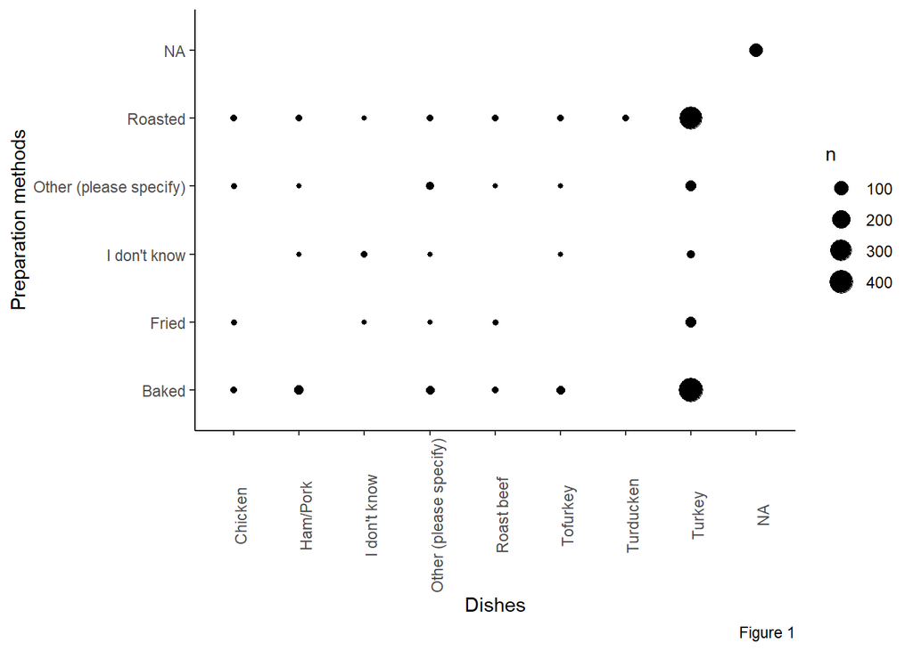

```r
ggplot(thanksgiving, aes(main_dish, main_prep)) +
  geom_count() + theme_classic() +
  labs(x = "Dishes", y = "Preparation methods", caption = "Figure 1") +
  theme(axis.text.x = element_text(angle = 90))
```

The above graph with classic theme shows different dishes are prepared using several methods. It can be seen that Turkey is generally preferred roasted or baked. Very few dishes are fried and Turducken is always roasted.

#### Figure 2

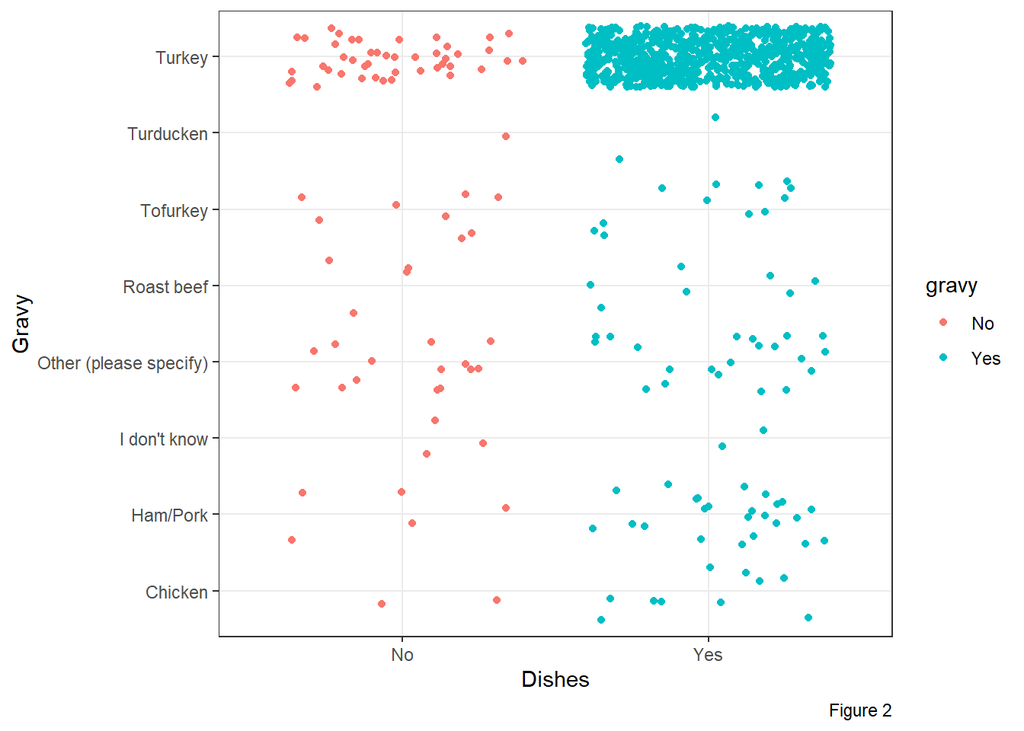

```r
thanksgiving %>%
  filter(!gravy == "NA") %>%
  ggplot(aes(gravy, main_dish, color = gravy)) +
  geom_jitter() + theme_bw() +
  labs(x = "Dishes", y = "Gravy", caption = "Figure 2")
```

The above graph in black and white theme shows that all the dishes can be prepared with or without gravy. But apparently we can say that people prefer to make their dishes with gravy. This graph excludes NA responses in Gravy.

#### Figure 3

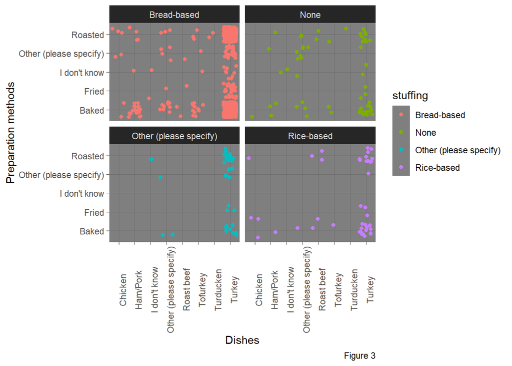

```r
thanksgiving %>%
  filter(!stuffing == "NA") %>%
  ggplot(aes(main_dish, main_prep, color = stuffing)) +
  geom_jitter() + theme_dark() +
  facet_wrap(~ stuffing) +
  labs(x = "Dishes", y = "Preparation methods", caption = "Figure 3")+
  theme(axis.text.x = element_text(angle = 90))
```

The above dark theme graphs show variety of dishes cooked with different stuffing. We can see that more dishes are prepared with bread based stuffing as compared to rice based or others. Turducken rarely has any stuffing. However, Turkey is rarely prepared without stuffing and most preferred stuffing is bread based.

### 7.How many use cranberry sauce? How many use gravy?

828 out of 1058 used cranberry sauce.(25 used other, 502 canned and 301 homemade)

```r
thanksgiving %>%
  count(cranberry)
```

```
##                cranberry   n
## 1                 Canned 502
## 2               Homemade 301
## 3                   None 146
## 4 Other (please specify)  25
## 5                   <NA>  84
```

892 out of 1058 used gravy.

```r
thanksgiving %>%
  count(gravy)
```

```
##   gravy   n
## 1    No  82
## 2   Yes 892
## 3  <NA>  84
```

### 8-9. Distribution of those who celebrate across income ranges.

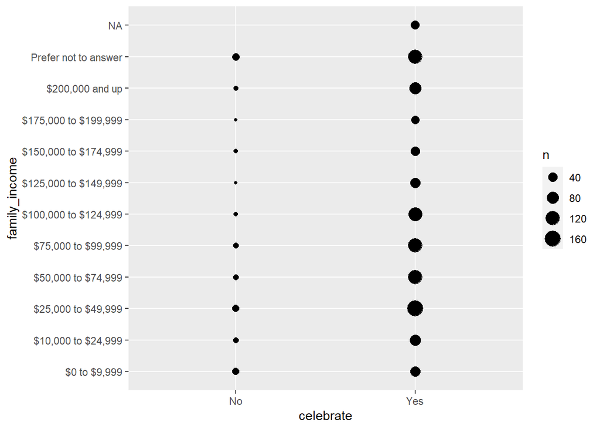

```r
thanksgiving %>%
  ggplot(aes(celebrate,family_income)) + theme_grey() +
  geom_count()
```

From the graph we can see that majority of the families (who participated in the poll) celebrate thanksgiving. Family income from the range of $25000 to $124999 has the most number of families celebrating thanksgiving. Even, families who did not prefer to disclose their income tend to celebrate. Among all the family income groups, the families celebrating were significantly high as compared to those who did not celebrate. All the participants stating NA in family income celebrated thanksgiving.

### 10. Use the following code to create a new data set

```r
thanksgiving_new <- thanksgiving %>%
  select(id, starts_with("side"), starts_with("pie"), starts_with("dessert")) %>%
  select(-side15, -pie13, -dessert12) %>%
  gather(type, value, -id) %>%
  filter(!is.na(value),
         !value %in% c("None", "Other (please specify)")) %>%
  mutate(type = str_remove(type, "\\d+"))

kable(thanksgiving_new)
```

| id | type | value |
| --- | --- | --- |
| 4337935621 | side | Brussel sprouts |
| 4337933040 | side | Brussel sprouts |
| 4337931983 | side | Brussel sprouts |
| 4337929779 | side | Brussel sprouts |
| 4337914977 | side | Brussel sprouts |
| 4337899817 | side | Brussel sprouts |
| 4337820281 | side | Brussel sprouts |
| 4337790002 | side | Brussel sprouts |
| 4337783794 | side | Brussel sprouts |
| 4337778119 | side | Brussel sprouts |
| 4337772193 | side | Brussel sprouts |
| 4337771439 | side | Brussel sprouts |
| 4337743121 | side | Brussel sprouts |
| 4337653684 | side | Brussel sprouts |
| 4337646565 | side | Brussel sprouts |
| 4337627331 | side | Brussel sprouts |
| 4337545841 | side | Brussel sprouts |
| 4337490067 | side | Brussel sprouts |
| 4337484305 | side | Brussel sprouts |
| 4337423740 | side | Brussel sprouts |
| 4337421462 | side | Brussel sprouts |
| 4337391263 | side | Brussel sprouts |
| 4337360752 | side | Brussel sprouts |
| 4337360389 | side | Brussel sprouts |
| 4337309060 | side | Brussel sprouts |
| 4337262725 | side | Brussel sprouts |
| 4337249904 | side | Brussel sprouts |
| 4337229414 | side | Brussel sprouts |
| 4337184092 | side | Brussel sprouts |
| 4337168468 | side | Brussel sprouts |

[output cut: 8115 more lines]

```r
thanksgiving_new %>%
 filter(id ==  4335894916)
```

```
##           id    type               value
## 1 4335894916    side                Corn
## 2 4335894916    side Macaroni and cheese
## 3 4335894916     pie           Chocolate
## 4 4335894916 dessert            Brownies
```

### 11-12. Intall package ‘widyr’ and use ‘pairwise_cor()’ function

https://www.rdocumentation.org/packages/widyr/versions/0.1.3/topics/pairwise_cor.

The pairwise cor() function calculates the correlation between the items. Here we are calculating correlation between the values chosen by each id. The result creates two columns- item 1 and item 2 and calculates the correlation of both these items. This will calculate interdependency of one dish with all the other dishes.The function sort is rearranging the correlation in descending order.

```r
#install.packages("widyr")
library(widyr)
thanksgiving_new%>%
  pairwise_cor(value, id, sort = TRUE)
```

```
## # A tibble: 992 x 3
##    item1               item2               correlation
##    <chr>               <chr>                     <dbl>
##  1 Cookies             Brownies                  0.411
##  2 Brownies            Cookies                   0.411
##  3 Sweet Potato        Macaroni and cheese       0.365
##  4 Macaroni and cheese Sweet Potato              0.365
##  5 Rolls/biscuits      Mashed potatoes           0.341
##  6 Mashed potatoes     Rolls/biscuits            0.341
##  7 Peach cobbler       Sweet Potato              0.339
##  8 Sweet Potato        Peach cobbler             0.339
##  9 Pumpkin             Mashed potatoes           0.290
## 10 Mashed potatoes     Pumpkin                   0.290
## # ... with 982 more rows
```

The final outcome shows the group of items with the highest correlation first and the least correlated items at last. Here, it can be seen that Cookies and Brownies have the highest correlation among all, meaning, many families who choose cookies have also chosen brownies, similarly the one who choose Sweet potato have also chosen Macroni and cheese.

### 13. Data modelling to predict family income:

Using ‘lm()’ or ‘randomForest()’ function to build a model that predicts a family income based on data in the dataset. Comparing the 3 models using different set of input variables. Using different number of variables. Further, explaining choice of variables.

Firstly, we will identify the output variable. If the output variable is ‘numeric’ we use ‘lm’ function and if it is ‘character’/‘factor’ we use random forest function. Here, in the thanksgiving dataset, family income is ‘factor’ variable (converted in point 3 above) hence we will use random forest function for modelling.

```r
class(thanksgiving$family_income)
```

```
## [1] "factor"
```

```r
#install.packages("randomForest")
library(randomForest)
```

In the model 1 (rf1) we are trying to predict family income with the help of three variables: age, community type and gender.

```r
rf1 <- randomForest(family_income ~ age + community_type + gender, data = thanksgiving, na.action=na.omit)

print(rf1)
```

```
##
## Call:
##  randomForest(formula = family_income ~ age + community_type +      gender, data = thanksgiving, na.action = na.omit)
##                Type of random forest: classification
##                      Number of trees: 500
## No. of variables tried at each split: 1
##
##         OOB estimate of  error rate: 82.37%
## Confusion matrix:
##                      $0 to $9,999 $10,000 to $24,999 $25,000 to $49,999
## $0 to $9,999                    3                  0                 45
## $10,000 to $24,999              2                  0                 50
## $25,000 to $49,999              3                  0                135
## $50,000 to $74,999              0                  0                111
## $75,000 to $99,999              3                  0                105
## $100,000 to $124,999            2                  0                 76
## $125,000 to $149,999            1                  0                 30
## $150,000 to $174,999            1                  0                 27
## $175,000 to $199,999            0                  0                 16
## $200,000 and up                 1                  0                 59
## Prefer not to answer            2                  0                103
##                      $50,000 to $74,999 $75,000 to $99,999 $100,000 to $124,999
## $0 to $9,999                          0                  0                    2
## $10,000 to $24,999                    0                  0                    4
## $25,000 to $49,999                    2                  1                   11
## $50,000 to $74,999                    0                  0                   14
## $75,000 to $99,999                    0                  0                   18
## $100,000 to $124,999                  0                  0                   28
## $125,000 to $149,999                  0                  0                   17
## $150,000 to $174,999                  0                  0                    9
## $175,000 to $199,999                  0                  0                   10
## $200,000 and up                       0                  0                   15
## Prefer not to answer                  0                  0                   12
##                      $125,000 to $149,999 $150,000 to $174,999
## $0 to $9,999                            0                    0
## $10,000 to $24,999                      0                    0
## $25,000 to $49,999                      0                    0
## $50,000 to $74,999                      0                    0
## $75,000 to $99,999                      0                    0
## $100,000 to $124,999                    0                    0
```

[output cut: 14 more lines]

```
## $175,000 to $199,999                    0               0                    0
## $200,000 and up                         0               0                    1
## Prefer not to answer                    0               0                    1
##                      class.error
## $0 to $9,999           0.9423077
## $10,000 to $24,999     1.0000000
## $25,000 to $49,999     0.1867470
## $50,000 to $74,999     1.0000000
## $75,000 to $99,999     1.0000000
## $100,000 to $124,999   0.7431193
## $125,000 to $149,999   1.0000000
## $150,000 to $174,999   1.0000000
## $175,000 to $199,999   1.0000000
## $200,000 and up        1.0000000
## Prefer not to answer   0.9915254
```

In the model 2 (rf2) we are trying to predict family income with the help of four variables: age, community type, gender and friendsgiving

```r
rf2 <- randomForest(family_income ~ age + community_type + gender + friendsgiving, data = thanksgiving, na.action=na.omit)

print(rf2)
```

```
##
## Call:
##  randomForest(formula = family_income ~ age + community_type +      gender + friendsgiving, data = thanksgiving, na.action = na.omit)
##                Type of random forest: classification
##                      Number of trees: 500
## No. of variables tried at each split: 2
##
##         OOB estimate of  error rate: 83%
## Confusion matrix:
##                      $0 to $9,999 $10,000 to $24,999 $25,000 to $49,999
## $0 to $9,999                   10                  0                 22
## $10,000 to $24,999              4                  0                 29
## $25,000 to $49,999             16                  0                 89
## $50,000 to $74,999              3                  0                 66
## $75,000 to $99,999              7                  0                 70
## $100,000 to $124,999            3                  0                 56
## $125,000 to $149,999            2                  0                 18
## $150,000 to $174,999            2                  0                 19
## $175,000 to $199,999            1                  0                  9
## $200,000 and up                 2                  0                 41
## Prefer not to answer            6                  0                 53
##                      $50,000 to $74,999 $75,000 to $99,999 $100,000 to $124,999
## $0 to $9,999                          4                  3                    2
## $10,000 to $24,999                    4                  3                    6
## $25,000 to $49,999                   12                 10                   19
## $50,000 to $74,999                    7                  7                   19
## $75,000 to $99,999                    9                 10                   22
## $100,000 to $124,999                  5                  7                   25
## $125,000 to $149,999                  4                  1                   21
## $150,000 to $174,999                  3                  1                   12
## $175,000 to $199,999                  3                  0                   11
## $200,000 and up                       5                  2                   20
## Prefer not to answer                 15                  6                   17
##                      $125,000 to $149,999 $150,000 to $174,999
## $0 to $9,999                            0                    0
## $10,000 to $24,999                      0                    0
## $25,000 to $49,999                      0                    0
## $50,000 to $74,999                      0                    0
## $75,000 to $99,999                      0                    0
## $100,000 to $124,999                    1                    0
```

[output cut: 14 more lines]

```
## $175,000 to $199,999                    0               0                    2
## $200,000 and up                         0               0                    6
## Prefer not to answer                    0               1                   20
##                      class.error
## $0 to $9,999           0.8076923
## $10,000 to $24,999     1.0000000
## $25,000 to $49,999     0.4638554
## $50,000 to $74,999     0.9448819
## $75,000 to $99,999     0.9212598
## $100,000 to $124,999   0.7706422
## $125,000 to $149,999   1.0000000
## $150,000 to $174,999   1.0000000
## $175,000 to $199,999   1.0000000
## $200,000 and up        1.0000000
## Prefer not to answer   0.8305085
```

In the model 3 (rf3) we are trying to predict family income with the help of five variables: age, community type, gender, friendsgiving and us region

```r
rf3 <- randomForest(family_income ~ age + community_type + gender + friendsgiving + us_region, data = thanksgiving, na.action=na.omit)

print(rf3)
```

```
##
## Call:
##  randomForest(formula = family_income ~ age + community_type +      gender + friendsgiving + us_region, data = thanksgiving,      na.action = na.omit)
##                Type of random forest: classification
##                      Number of trees: 500
## No. of variables tried at each split: 2
##
##         OOB estimate of  error rate: 86.25%
## Confusion matrix:
##                      $0 to $9,999 $10,000 to $24,999 $25,000 to $49,999
## $0 to $9,999                   11                  2                 14
## $10,000 to $24,999              3                  0                 30
## $25,000 to $49,999             13                  3                 53
## $50,000 to $74,999              4                  3                 53
## $75,000 to $99,999              6                  2                 57
## $100,000 to $124,999            1                  1                 37
## $125,000 to $149,999            1                  1                 17
## $150,000 to $174,999            4                  0                 13
## $175,000 to $199,999            1                  0                  6
## $200,000 and up                 2                  1                 29
## Prefer not to answer            8                  1                 41
##                      $50,000 to $74,999 $75,000 to $99,999 $100,000 to $124,999
## $0 to $9,999                          7                  4                    2
## $10,000 to $24,999                    9                  7                    1
## $25,000 to $49,999                   26                 23                   19
## $50,000 to $74,999                   10                 14                   18
## $75,000 to $99,999                   12                 12                   19
## $100,000 to $124,999                 16                 16                   21
## $125,000 to $149,999                  3                  5                   11
## $150,000 to $174,999                  2                  3                   11
## $175,000 to $199,999                  3                  1                    9
## $200,000 and up                      11                  8                   18
## Prefer not to answer                 14                 15                   15
##                      $125,000 to $149,999 $150,000 to $174,999
## $0 to $9,999                            0                    0
## $10,000 to $24,999                      1                    0
## $25,000 to $49,999                      3                    0
## $50,000 to $74,999                      5                    1
## $75,000 to $99,999                      4                    0
## $100,000 to $124,999                    6                    1
```

[output cut: 14 more lines]

```
## $175,000 to $199,999                    0               3                    2
## $200,000 and up                         0               1                    3
## Prefer not to answer                    1               4                   15
##                      class.error
## $0 to $9,999           0.7608696
## $10,000 to $24,999     1.0000000
## $25,000 to $49,999     0.6728395
## $50,000 to $74,999     0.9206349
## $75,000 to $99,999     0.9047619
## $100,000 to $124,999   0.8073394
## $125,000 to $149,999   0.8958333
## $150,000 to $174,999   1.0000000
## $175,000 to $199,999   1.0000000
## $200,000 and up        0.9866667
## Prefer not to answer   0.8717949
```

### Reason for choosing the variable:

Age: Generally, people as they grow older, tend to earn more money as they get more experience and knowledge with the passage of time.

Community type and us region: People from urban area tend to earn more as compared to rural area mainly because developed regions provide more employment oppurtunities and infrastructure than the developing or under developed regions.

Gender: Depending on the locality, there can be possibility that there exists gender pay gaps (males have higher income then women)

Friendsgiving: People with less income might celebrate only with the family (less people) and hence do not have friendsgiving and vice versa.

### Explaining which model is best.

Model 1 and model 2 are providing almost similar error rates while model 3 is providing a higher error rate as compared to the other two models. Hence in comparision, Model 1 or Model 2 are better than Model 3. But The error rates of all the models are above 80% and hence all the models are not recommended as they won’t be able to predict family income accurately.